# Statistics for Psychologists 3.

**Computer lab 05**

**Course Number:** BTPS2040BA-E  
**Contact Information:** Please contact me through email anytime: abari.kalman@arts.unideb.hu

Author

Kálmán Abari

Published

March 15, 2025

Learning outcomes

Student will be familiar with file and directory handling.

**To earn 1 point**

To earn 1 point, submit all jamovi OMV files in this Computer lab that contain the activities you completed here. The subject of the email should be `Stat3 - Comp. lab 05`. Send the email to `abari.kurzus@gmail.com`.

# Worked Example 1

A fictitious database contains the school grades of 9 students in real subjects (mathematics, physics, chemistry, computer science) (`reliabilty_subjects.xlsx`). Let’s examine whether if we measured the susceptibility to real subjects with these 4 grades, this would be a suitable measuring instrument in terms of reliability.

## Step 1. Import database

Open the `reliability_subjects.xlsx` file in jamovi.

Our database contains the grades of four subjects (mathematics, physics, informatics, chemistry).

[figure not shown]

## Step 2. Measure type

Set the measurement level of the variables. All variables are continuous, so we set the measurement level to `Continuous`.

[figure not shown]

## Step 3. Cronbach’s alpha

To display the reliability of the measuring instrument, we use Cronbach’s alpha. To do this, we select the `Factor` icon from the `Analysis` tab, than select `Reliability Analysis`. We add the four variables to the `Items` section. The goal is to see how well the four academic subjects (mathematics, physics, informatics, chemistry) form a reliable scale.

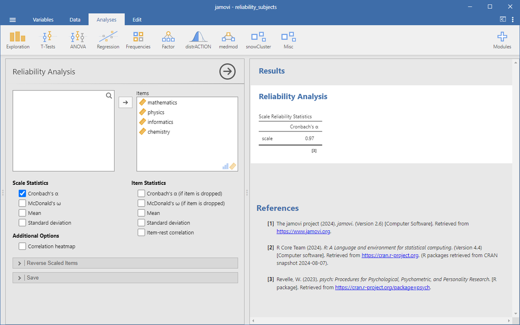

Looking at the image, we can see a reliability analysis conducted in Jamovi statistical software.

#### What can be interpreted from the results:

1. The reliability analysis shows a Cronbach’s alpha value of 0.97 for the scale comprised of the four academic subjects.
2. This extremely high alpha value (0.97) indicates excellent internal consistency reliability among these four items. Values above 0.90 typically suggest very strong internal consistency.
3. High reliability coefficient suggests these four academic subjects could effectively be combined into a single scale, perhaps measuring general STEM aptitude or performance.

## Step 4. Correlation heatmap

To display the Correlation heatmap of the variables, check the `Correlation heatmap` box below the `Additional output`. The goal is to see how the variables are correlated with each other.

[figure not shown]

Based on the correlation heatmap shown in the Jamovi output, I can provide the following interpretation:

- The heatmap displays Pearson correlation coefficients between four academic subjects: mathematics, physics, informatics, and chemistry. Here’s what can be observed:
- All correlations are positive and strong (ranging from 0.77 to 0.95), indicating that performance in these subjects is highly related.
- The strongest correlations are:
  - Between mathematics and chemistry (0.95)
  - Between mathematics and informatics (0.95)
  - Between chemistry and physics (0.93)
- The weakest correlation, though still strong, is between physics and informatics (0.77).
- Chemistry and informatics have a strong correlation of 0.89.
- Mathematics and physics show a strong correlation of 0.87.
- The diagonal values are all 1.0, which is expected as this represents the correlation of each variable with itself.
- The color intensity (green) represents the strength of the positive correlations, with darker green indicating stronger positive relationships.

These consistently high correlations explain the very high Cronbach’s alpha value of 0.97 shown in the reliability analysis, confirming that these four subjects measure related academic constructs and could effectively form a single scale measuring general STEM aptitude or performance.

## Step 5. Item statistics

To display the Item statistics, check the `Cronbach's α if item dropped` box below `Item statistics`. The goal is to see how the removal of each item would affect the overall reliability of the scale.

[figure not shown]

Based on the image, the Item Reliability Statistics table shows the “Cronbach’s α if item dropped” values for each of the four academic subjects in the analysis. Here’s what these values indicate:

- Mathematics: 0.94 - If mathematics were removed from the scale, the Cronbach’s alpha would decrease from 0.97 to 0.94.
- Physics: 0.97 - If physics were removed, the Cronbach’s alpha would remain unchanged at 0.97.
- Informatics: 0.96 - If informatics were removed, the Cronbach’s alpha would decrease slightly to 0.96.
- Chemistry: 0.94 - If chemistry were removed, the Cronbach’s alpha would decrease from 0.97 to 0.94.

These statistics help assess the contribution of each item to the overall reliability of the scale. The relatively small changes in Cronbach’s alpha when individual items are removed suggest that:

- All four subjects contribute positively to the scale’s reliability, since none of the “if item dropped” values exceeds the original alpha of 0.97.
- Physics appears to contribute the least to scale reliability, as removing it doesn’t change the overall Cronbach’s alpha.
- Mathematics and chemistry seem to be the most important items for maintaining scale reliability, as removing either one would cause the largest drop in Cronbach’s alpha (from 0.97 to 0.94).
- The high alpha values even when items are removed (all ≥ 0.94) indicate that the scale would remain highly reliable regardless of which item is removed.

This analysis supports the conclusion that these four academic subjects form a highly reliable measure, with particularly strong contributions from mathematics and chemistry.

# Worked Example 2

HERTDAQ Bank assesses how satisfied its customers are with the speed of service. It develops the following four questions:

- item 1: “My telephone, e-mail or letter inquiry was answered within a reasonable time.”
- item 2: “I am satisfied with the speed of service provided.”
- item 3: “The waiting time for services was reasonable.”
- item 4: “I am satisfied with the services received.”

The above items could be answered using a 5-point Likert scale, with values ranging from 1 (strongly disagree) to 5 (strongly agree). A total of 60 customers were asked to complete the survey in the preliminary testing phase, before the survey was distributed more widely.

1. Perform a reliability test of the “speed of service” scale using Cronbach’s alpha and principal component analysis!
2. Do you suggest omitting items? Why?

## Step 1. Import database

Open the `reliability_banking_speed.csv` file in jamovi. Our database contains the responses of 60 customers to the four items.

[figure not shown]

## Step 2. Measure type

Set the measurement level of the variables. All variables are continuous, so we set the measurement level to `Continuous`.

[figure not shown]

## Step 3. Cronbach’s alpha

To display the reliability of the measuring instrument, we use Cronbach’s alpha. To do this, we select the `Factor` icon from the `Analysis` tab, than select `Reliability Analysis`. We add the four variables to the `Items` section. The goal is to see how well the four items form a reliable scale.

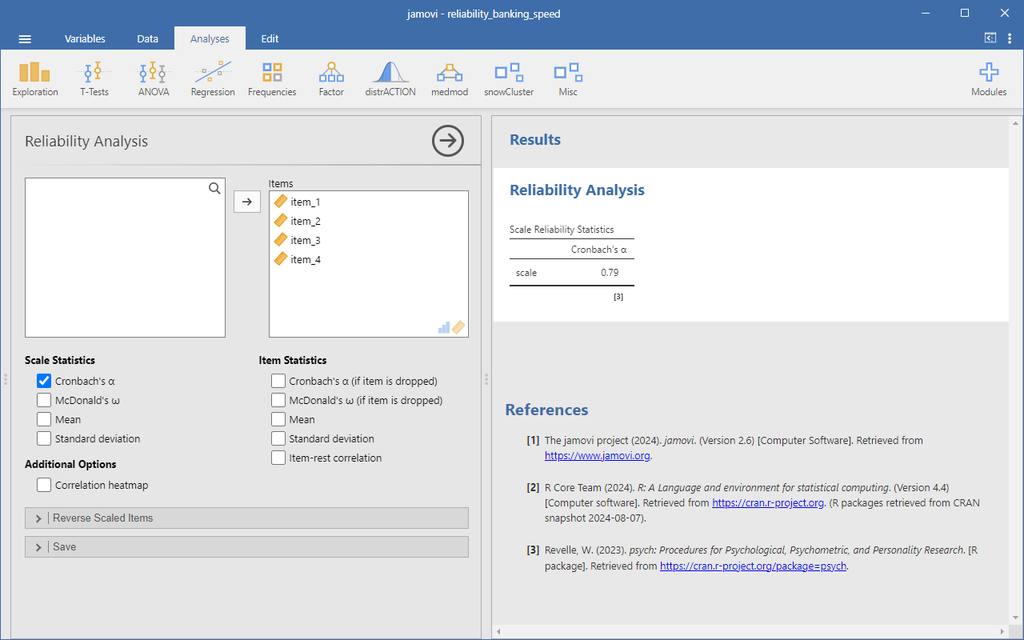

This image shows a reliability analysis conducted in jamovi with four items: item_1, item_2, item_3, and item_4.

The key findings from this analysis are:

- Cronbach’s alpha value of 0.79 for the scale, which indicates acceptable internal consistency reliability. This value suggests that the four items are reasonably cohesive in measuring the same underlying construct, though not as strongly related as the academic subjects in the previous analysis (which had an alpha of 0.97).
- This analysis is examining the reliability of a scale measuring some aspect of banking service speed or efficiency, with the four items potentially representing different questions or metrics related to this construct.
- Without additional information like the correlation matrix or “if item dropped” statistics, we can’t determine which items might be contributing more or less to the scale’s reliability.

## Step 4. Item statistics

To display the Item statistics, check the `Cronbach's α if item dropped` box below `Item statistics`. The goal is to see how the removal of each item would affect the overall reliability of the scale. To display the Correlation heatmap of the variables, check the `Correlation heatmap` box below the `Additional output`. The goal is to see how the variables are correlated with each other.

[figure not shown]

This image shows additional reliability analysis statistics for the banking speed scale, with two key sections now visible:

1. **Item Reliability Statistics (Cronbach’s α if item dropped):**

```
-   item_1: 0.60 - If removed, alpha drops substantially from 0.79 to 0.60

-   item_2: 0.61 - If removed, alpha drops from 0.79 to 0.61

-   item_3: 0.63 - If removed, alpha drops from 0.79 to 0.63

-   item_4: 0.92 - If removed, alpha would increase significantly from 0.79 to 0.92
```

2. **Correlation Heatmap:**
   - Strong correlations:
     - item_1 and item_2: 0.81
     - item_1 and item_3: 0.79
     - item_2 and item_3: 0.79
   - Extremely weak correlations:
     - item_1 and item_4: 0.04 (essentially uncorrelated)
     - item_2 and item_4: 0.02 (essentially uncorrelated)
     - item_3 and item_4: 0.00 (zero correlation)
3. These results reveal that item_4 is problematic and likely measuring a completely different construct than the other three items:
4. The dramatically higher alpha (0.92) if item_4 is removed suggests it’s actually reducing the scale’s reliability
5. The correlation matrix confirms this by showing item_4 has virtually no correlation with any other items in the scale
6. Items 1, 2, and 3 are strongly intercorrelated (0.79-0.81), indicating they measure the same construct

This analysis strongly suggests that item_4 should be removed from the scale to improve its reliability and construct validity. After removal, the resulting three-item scale would have excellent internal consistency (α = 0.92) and consist of items that clearly measure the same underlying construct.

The findings demonstrate why examining both “if item dropped” statistics and correlation patterns is crucial when assessing scale reliability.

## Step 5. Item statistics after removing item_4

Remove the `item_4` from the `Items` section and take a look at the `Cronbach's α if item dropped` statistics.

[figure not shown]

This image shows the updated reliability analysis after removing item_4 from the scale, as was suggested by the previous analysis. We’ll explain the key changes and current findings:

1. **Scale Composition:**

```
-   The scale now consists of only three items: item_1, item_2, and item_3

-   item_4 has been removed (it appears in the search box on the left but is no longer in the "Items" section)
```

2. **Item Reliability Statistics:**

[output not shown]

3. **Correlation Heatmap:**

```
-   The correlation matrix now shows only the relationships between the three remaining items

-   item_1 and item_2: 0.81 (strong correlation)

-   item_1 and item_3: 0.79 (strong correlation)

-   item_2 and item_3: 0.79 (strong correlation)
```

4. **Improvements After Removing item_4:**

```
-   The scale reliability has improved significantly

-   All three items now show strong intercorrelations

-   The "if item dropped" values suggest a more cohesive scale
```

This analysis confirms that removing item_4 was the right decision. The three-item scale now demonstrates excellent internal consistency with all items contributing positively to the scale’s reliability. The correlations between all items are strong and consistent (0.79-0.81), indicating they are measuring the same underlying construct related to banking speed.

# Worked Example 3

The researcher was interested in what benefits consumers look for when purchasing toothpaste. In a sample of 30 people, respondents were asked to indicate the extent to which they agreed with the following statements (1 = strongly disagree; 7 = strongly agree):

- v1: It is important for me to buy toothpaste that prevents tooth decay.
- v2: I like toothpaste that makes my teeth shine.
- v3: A toothpaste should strengthen my gums.
- v4: I like toothpaste that provides fresh breath.
- v5: Preventing tooth decay is not an important expectation for me.
- v6: The most important consideration when buying toothpaste is beautiful teeth.

Based on previous research, the researchers assume that the questionnaire has 2 subscales:

- the health subscale and
- the aesthetics scale.

Each subscale consists of the following items: - the health subscale: v1, v3, v5 (reverse coded) - the aesthetics scale. v2, v4, v6.

Let’s examine whether the two subscales have good reliability. Remember, the reliability analysis has to be conducted separately for the two subscales. There is a reverse-coded item in the health subscale, so we have to reverse the coding of the item before conducting the reliability analysis.

## Step 1. Import database

Open the `reliability_toothpaste.xlsx` file in jamovi. Our database contains the responses of 30 people to the six items.

[figure not shown]

## Step 2. Measure type

Set the measurement level of the variables. All variables are continuous, so we set the measurement level to `Continuous`.

[figure not shown]

## Step 3. Reliability analysis for the health subscale

To conduct the reliability analysis for the health subscale, we need to add the three health-related items (v1, v3, v5) to the `Items` section. Since item v5 is reverse-coded, we need to reverse the coding below the `Reverse Scaled Items` dropdown menu.

[figure not shown]

This image shows a reliability analysis for a subscale of the toothpaste questionnaire focused on health-related benefits. Here’s a breakdown of the key components and findings from this analysis:

1. **Scale Composition and Overview:**
   - Three items are included in the analysis: v1, v3, and v5
   - The scale has a very high Cronbach’s alpha of 0.94, indicating excellent internal consistency
2. **Item Reliability Statistics:**

```
-   v1: If removed, alpha would decrease to 0.87
-   v3: If removed, alpha would decrease to 0.92
-   v5\*: If removed, alpha would decrease to 0.92 (\*note: v5 is reverse scaled)
```

3. **Correlation Heatmap:**

```
-   v1 and v3: Strong correlation of 0.86

-   v1 and v5: Strong correlation of 0.86

-   v3 and v5: Strong correlation of 0.77
```

4. **Reverse Scaled Items Section:**

```
-   The red-boxed area shows the "Reverse Scaled Items" dialog is open

-   v5 has been designated as a reverse scaled item (noted by the asterisk in the results table)

-   v1 and v3 are shown as normal scaled items
```

The reverse scaling of v5 indicates that this item was worded in the opposite direction compared to the other items. For example, if v1 and v3 were positively worded questions about toothpaste satisfaction (higher scores = more satisfaction), v5 was likely negatively worded (higher scores = less satisfaction). Jamovi has reversed the scoring for v5 before calculating the reliability statistics to ensure consistency in interpretation.

All three items contribute well to the scale’s reliability, with v1 appearing to be the most critical item (removing it would cause the largest drop in alpha). The strong inter-item correlations and high Cronbach’s alpha suggest these three items form a highly reliable measure for the toothpaste-related construct being assessed.

## Step 4. Reliability analysis for the aesthetics subscale

Please, conduct the reliability analysis for the aesthetics subscale. Add the three aesthetics-related items (v2, v4, v6) to the `Items` section. Answer the following questions:

- What is the Cronbach’s alpha value for the aesthetics subscale?
- Can we ommitt any of the items?
- Can the aesthetics subscale be considered reliable?